# 2. Guided Partial Least Squares (guided-PLS)

Koki Tsuyuzaki

Laboratory for Bioinformatics Research, RIKEN Center for Biosystems Dynamics Research  
k.t.the-answer@hotmail.co.jp

2023-03-22

# Introduction

In this vignette, we consider a novel supervised dimensional reduction method guided partial least squares (guided-PLS).

Test data is available from `toyModel`.

```r
library("guidedPLS")
data <- guidedPLS::toyModel("Easy")
str(data, 2)
```

```
## List of 8
##  $ X1      : int [1:100, 1:300] 86 101 95 106 113 85 88 103 106 84 ...
##  $ X2      : int [1:200, 1:150] 106 81 91 101 91 105 111 81 113 105 ...
##  $ Y1      : int [1:100, 1:50] 101 77 77 87 101 89 111 113 101 112 ...
##  $ Y1_dummy: num [1:100, 1:3] 1 1 1 1 1 1 1 1 1 1 ...
##  $ Y2      : int [1:200, 1:50] 107 81 102 90 84 106 97 90 88 115 ...
##  $ Y2_dummy: num [1:200, 1:3] 1 1 1 1 1 1 1 1 1 1 ...
##  $ col1    : chr [1:100] "#66C2A5" "#66C2A5" "#66C2A5" "#66C2A5" ...
##  $ col2    : chr [1:200] "#66C2A5" "#66C2A5" "#66C2A5" "#66C2A5" ...
```

You will see that there are three blocks in the data matrix as follows.

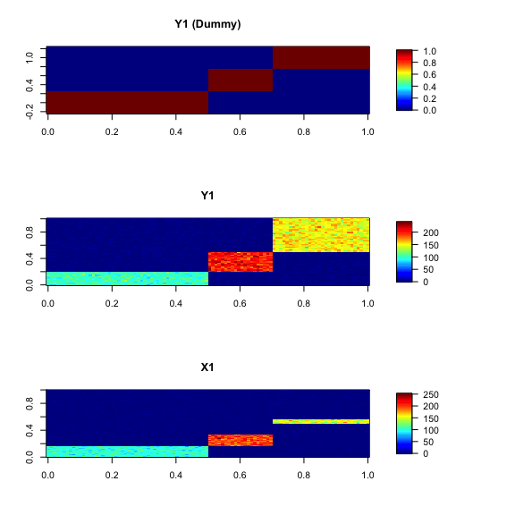

```r
suppressMessages(library("fields"))
layout(c(1,2,3))
image.plot(data$Y1_dummy, main="Y1 (Dummy)", legend.mar=8)
image.plot(data$Y1, main="Y1", legend.mar=8)
image.plot(data$X1, main="X1", legend.mar=8)
```

# Guided Partial Least Squares (guided-PLS)

Here, suppose that we have two data matrices $X_1$ ($N \times M$) and $X_2$ ($S \times T$), and the column vectors of them are assumed to be centered. Since these two matrices have no common row or column, integration of them is not trivial. Such a data structure is called “diagonal” and known as a barrier to omics data integration (Argelaguet 2021).

In guided-PLS, the data matrices $X_1$ and $X_2$ are projected into lower dimension via $Y_1$ and $Y_2$, and then PLS-SVD are performed against the $Y_{1} X_{1}$ and $Y_{2} X_{2}$ as follows:

$$\max_{W_{1},W_{2}} \mathrm{tr}
\left(
W_{1}^{T} X_{1}^{T} Y_{1}^{T} Y_{2} X_{2} W_{2}
\right)\ \mathrm{s.t.}\ W_{1}^{T}W_{1} = W_{2}^{T}W_{2} = I_{K}$$

## Basic Usage

`guidedPLS` is performed as follows.

```r
out <- guidedPLS(X1=data$X1, X2=data$X2, Y1=data$Y1, Y2=data$Y2, k=2)
```

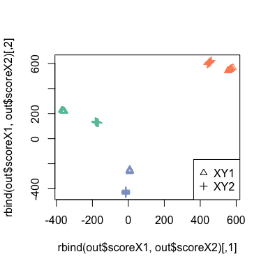

```r
plot(rbind(out$scoreX1, out$scoreX2), col=c(data$col1, data$col2),
pch=c(rep(2, length=nrow(out$scoreX1)), rep(3, length=nrow(out$scoreX2))))
legend("bottomright", legend=c("XY1", "XY2"), pch=c(2,3))
```

# References

Argelaguet, et al., R. 2021. “Computational Principles and Challenges in Single-Cell Data Integration.” *Nature Biotechnology* 39: 1202–15.